# Introduction to R and RStudio

Danh Truong

## What is R?

R is a language and environment for statistical computing and graphics. It is widely used for a variety of statistical analysis (i.e., linear and nonlinear modeling, classical statistical tests, clustering, etc.). We can also use R for data visualization and producing figures for presentations. R is freely available and has a large collection of developed packages of different tools. Overall, R is a powerful tool that can be used to handle big data, perform statistics, and visualize results, while enabling end-users to easily develop tools and packages for customized functionality.

## What is RStudio?

While R, also called “base R”, itself is an interpreted computer language and comes with a terminal, ease of use and more functionality is introduced when using RStudio, an open source Integrated Development Environment (IDE). Rather than using a terminal, RStudio provides a graphical user interface that is platform agnostic and integrates additional packages, project management, version control, and notebooks.

## Getting started with R and RStudio

[The Comprehensive R Archive Network](https://cran.r-project.org) or CRAN actively maintains and develops R. It also hosts a repository of R packages that enhances the base functionality of R. To get started, base R can be installed on either Linux, macOS, or Windows by going to the [CRAN](https://cran.r-project.org) homepage.

To use R, you need to open a terminal window and type `R` and press enter. You will see some text denoting the R version and some helpful functions. To quit, type `q()` and press enter.

Rather than work in a terminal, RStudio is the way to use R like how many use Microsoft Word to prepare documents. Download RStudio for free [here](https://www.rstudio.com/products/rstudio/) and follow the installation instructions. Once installed, proceed to opening RStudio, typically done by clicking on the RStudio icon.

Once you open RStudio, you will see four main panes. Each will contain different information. You can see my screen below.

[figure not shown]

Starting from the top left pane and going from left to right, we have the descriptions of each pane below:

1. **Source Editor**: This pane is where you can write R scripts or notebooks. You can write in other programming languages if you wanted to as well. Each document will have its own tab. Code written here can be run with the `Run` command.
2. **Environment**: This pane displays objects, variables, and functions that are generated in your R session. There is also a history of all code that was run.
3. **Console**: This pane is where you can type commands and interactively run R code. The output will display in the console.
4. **Files, Plots, Packages, Help, Viewer**: This pane has several tabs that are important.
   - *Files*: This tab shows the structure and content of a directory on your computer. This could be your working directory or a directory that you manually navigated to.
   - *Plots*: This tab will display plots or figures as an output from the console.
   - *Packages*: This tab contains a list of all packages that are installed. Packages that are loaded in your R session will have a checked box.
   - *Help*: This tab reveals the help pages for an R package or function.
   - *Viewer*: This tab shows compiled R Markdown documents.

## Starting a new project in RStudio

When working with R, it is always a good idea to create a new project directory. This will help you keep your files and data organized by project.

To get started: 1. Open RStudio 2. Go to the File menu and select New Project. 3. In the New Project window, choose New Directory. Then, choose New Project. Name your new directory. You can use a name like, Intro-to-R, and then “Create the project as subdirectory of:” in a location of your choice. 4. Click on Create Project. 5. The project should open up automatically in Rstudio.

We can view our working directory by using the function `getwd()`

```r
getwd()
```

```r
[1] "/Users/dtruong4/Desktop/Intro-to-R"
```

Your working directory will be the location where R will automatically look for files. If you want to find files in a different location, you will either need to provide the full path or type the path in relation to the working directory. Files that you output will automatically save into your working directory unless a path is provided.

To organize your working directory, it is highly recommended to generate sub-folders like `data/` or `results/`. You can do so in the Files tab and select `New Folder`.

## Basic math calculations in R

Below are some of the most common math calculations that can be done in R.

| Operation | Symbol |
| --- | --- |
| Addition | `a + b` |
| Subtraction | `a - b` |
| Multiplication | `a * b` |
| Division | `a / b` |
| Exponent | `a ^ b` |
| Remainder | `a %% b` |
| Integer Division | `a %/% b` |

For instance, here is an example of addition.

```r
5 + 3
```

## Functions in R

R has several pre-built functions. For instance, we can use `sum()` instead of the `+` symbol for addition.

```r
sum(1,3) #This gives the sum of 1 and 3
```

We can also call the *R documentation* for a function by using `?` before the function name. The documentation will show up under the Help tab. It contains information regarding description, usage, and arguments for a function.

```r
?sum #Find the R Documentation for sum()
```

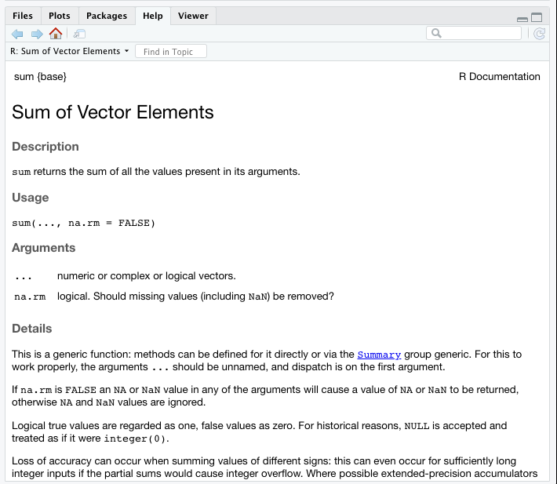

We can see that `sum()` can return the sum of more than two values.

```r
sum(1,2,3,4,5)
```

## Math functions in R

In addition to the basic calculations, there are many common pre-built math functions in R.

| Operation | Function |
| --- | --- |
| Square root | `sqrt()` |
| Logarithm | `log()` |
| Logarithm, base 10 | `log10()` |
| Exponential | `exp()` |
| Summation | `sum()` |
| Round | `round()` |
| Mean | `mean()` |
| Median | `median()` |
| Minimum | `min()` |
| Maximum | `max()` |

```r
#What is the square root of 4?
sqrt(4)
```

```r
#Can we round 3.14?
round(3.14)
```

## Defining variables

A key aspect of programming is defining variables. We store data or values as variables so that we can use in other functions or recall it at a later time. It allows us to save time by storing the data and not having to re-calculate it again. R has two *assignment operators* for defining variables: `<-` and `=`. The operator `<-` can be used anywhere, whereas the operator `=` is only allowed at the top level.

```r
x <- 1

#What is in `x`?
x
```

```r
y = 15.3

#What is in `y`?
y
```

```r
#What is in x + y?
x + y
```

We can also define variables within functions.

```r
sqrt(y <- 5)

#What is in `y`?
y
```

However, we cannot use the `=` to do so. This is because functions already have pre-defined arguments that the function is looking for. In this case, `sqrt()` is looking for the argument `x`, not `y`.

```r
sqrt(y = 5)
```

Instead, we can do the following:

```r
sqrt(x = y <- 5) #Here we define y as 5 and pass y into x
sqrt(x = 5) #Here we pass 5 into x
```

Importantly, when defining variable names, ensure that you use an *informative* name. This enables yourself and others when reviewing code to know how the variable was used. For instance, we used `x` and `y` in the examples, but their meaning is unknown. Something like `country_population` or `room_capacity` provides better definition for a variable.

## R Data Types

There are different types of data in R, which can be stored as a variable. Below is a table of some of the most commonly used data types.

| Data Type | Definition | Example |
| --- | --- | --- |
| numeric | Any number value | `3.14` |
| integer | Any whole number value | `42` |
| character | Any number of ASCII characters | `"Hello world!"` |
|  | defined within quotation marks |  |
| logical | A value of `TRUE` or `FALSE` | `TRUE` |
| factor | A categorical type of data | `#> [1] Male Male Male Female Female` |
|  |  | `#> Levels: Male Female` |

The function `class()` can be used to find out the type of data that you are dealing with.

```r
x <- 3
class(x)
```

```r
x <- TRUE
class(x)
```